# Practicum II / Part A

DA5030 / Decision Tree & Logistic Regression Classification

Daware, Aditya

Spring, 2025

## Reading the CSV files

```r
training.url <- "https://s3.us-east-2.amazonaws.com/artificium.us/datasets/parkinsons-diagnostic-data.csv"
df <- read.csv(training.url, stringsAsFactors = F)

validation.url <- "https://s3.us-east-2.amazonaws.com/artificium.us/datasets/parkinsons-diagnostic-validation-100.csv"
df.valid <- read.csv(validation.url, stringsAsFactors = F)
```

The CSV file is read and stored in variables.

## Exploratory Data Analysis

```r
head(df)
```

```
##   PatientID Age Gender Ethnicity EducationLevel      BMI Smoking
## 1      3058  85 Female        NA    High School 19.61988       0
## 2      3059  75 Female        NA        College 16.24734       1
## 3      3061  52 Female        NA           None 15.45456       0
## 4      3062  87 Female        NA    High School 18.61604       0
## 5      3064  78 Female        NA           None 30.54200       1
## 6      3065  70 Female        NA           None 36.75828       1
##   AlcoholConsumption PhysicalActivity DietQuality SleepQuality
## 1           5.108241         1.380660    3.893969     9.283194
## 2           6.027648         8.409804    8.513428     5.602470
## 3           5.997788         1.375045    6.715033     4.196189
## 4           9.775243         1.188607    4.657572     9.363925
## 5           2.011281         9.028536    9.838446     5.981984
## 6          19.988866         3.891749    3.421960     7.895866
##   FamilyHistoryParkinsons TraumaticBrainInjury Hypertension Diabetes Depression
```

[output cut: 34 more lines]

```r
str(df)
```

```
## 'data.frame':    2005 obs. of  34 variables:
##  $ PatientID               : int  3058 3059 3061 3062 3064 3065 3066 3067 3068 3069 ...
##  $ Age                     : int  85 75 52 87 78 70 80 71 70 53 ...
##  $ Gender                  : chr  "Female" "Female" "Female" "Female" ...
##  $ Ethnicity               : logi  NA NA NA NA NA NA ...
##  $ EducationLevel          : chr  "High School" "College" "None" "High School" ...
##  $ BMI                     : num  19.6 16.2 15.5 18.6 30.5 ...
##  $ Smoking                 : int  0 1 0 0 1 1 1 1 0 1 ...
##  $ AlcoholConsumption      : num  5.11 6.03 6 9.78 2.01 ...
##  $ PhysicalActivity        : num  1.38 8.41 1.38 1.19 9.03 ...
##  $ DietQuality             : num  3.89 8.51 6.72 4.66 9.84 ...
##  $ SleepQuality            : num  9.28 5.6 4.2 9.36 5.98 ...
##  $ FamilyHistoryParkinsons : int  0 0 0 0 0 0 0 0 0 0 ...
##  $ TraumaticBrainInjury    : int  0 0 0 0 0 0 0 1 0 0 ...
##  $ Hypertension            : int  0 0 0 0 1 0 0 0 0 0 ...
```

[output cut: 20 more lines]

```r
summary(df)
```

```
##    PatientID         Age          Gender          Ethnicity
##  Min.   :3058   Min.   :50.0   Length:2005        Mode:logical
##  1st Qu.:3584   1st Qu.:60.0   Class :character   NA's:2005
##  Median :4112   Median :70.0   Mode  :character
##  Mean   :4111   Mean   :69.7
##  3rd Qu.:4635   3rd Qu.:80.0
##  Max.   :5162   Max.   :89.0
##
##  EducationLevel          BMI           Smoking       AlcoholConsumption
##  Length:2005        Min.   :15.01   Min.   :0.0000   Min.   : 0.003563
##  Class :character   1st Qu.:20.79   1st Qu.:0.0000   1st Qu.: 5.125067
##  Mode  :character   Median :27.22   Median :0.0000   Median :10.120981
##                     Mean   :27.22   Mean   :0.2983   Mean   :10.062599
##                     3rd Qu.:33.50   3rd Qu.:1.0000   3rd Qu.:14.912089
##                     Max.   :40.00   Max.   :1.0000   Max.   :19.988866
##
##  PhysicalActivity    DietQuality        SleepQuality    FamilyHistoryParkinsons
##  Min.   :0.004157   Min.   :0.000011   Min.   : 4.013   Min.   :0.0000
##  1st Qu.:2.489607   1st Qu.:2.430635   1st Qu.: 5.487   1st Qu.:0.0000
##  Median :5.031550   Median :4.784695   Median : 6.936   Median :0.0000
##  Mean   :5.030945   Mean   :4.874636   Mean   : 7.000   Mean   :0.1436
##  3rd Qu.:7.567005   3rd Qu.:7.281984   3rd Qu.: 8.566   3rd Qu.:0.0000
##  Max.   :9.995255   Max.   :9.995864   Max.   :10.000   Max.   :1.0000
##                                        NA's   :4
##  TraumaticBrainInjury  Hypertension       Diabetes        Depression
##  Min.   :0.0000       Min.   :0.0000   Min.   :0.0000   Min.   :0.0
##  1st Qu.:0.0000       1st Qu.:0.0000   1st Qu.:0.0000   1st Qu.:0.0
##  Median :0.0000       Median :0.0000   Median :0.0000   Median :0.0
##  Mean   :0.1052       Mean   :0.1436   Mean   :0.1501   Mean   :0.2
##  3rd Qu.:0.0000       3rd Qu.:0.0000   3rd Qu.:0.0000   3rd Qu.:0.0
##  Max.   :1.0000       Max.   :1.0000   Max.   :1.0000   Max.   :1.0
##
##      Stroke          SystolicBP     DiastolicBP     CholesterolTotal
##  Min.   :0.00000   Min.   : 90.0   Min.   : 60.00   Min.   :150.1
##  1st Qu.:0.00000   1st Qu.:110.0   1st Qu.: 75.00   1st Qu.:189.0
##  Median :0.00000   Median :133.0   Median : 90.00   Median :228.4
##  Mean   :0.04788   Mean   :133.6   Mean   : 90.13   Mean   :226.6
##  3rd Qu.:0.00000   3rd Qu.:157.0   3rd Qu.:105.00   3rd Qu.:264.5
##  Max.   :1.00000   Max.   :179.0   Max.   :119.00   Max.   :300.0
##
```

[output cut: 17 more lines]

```
##  Min.   :0.0000   Min.   :0.0000      Min.   :0.0000   Min.   :0.0000
##  1st Qu.:0.0000   1st Qu.:0.0000      1st Qu.:0.0000   1st Qu.:0.0000
##  Median :0.0000   Median :0.0000      Median :0.0000   Median :0.0000
##  Mean   :0.2085   Mean   :0.1392      Mean   :0.2953   Mean   :0.2459
##  3rd Qu.:0.0000   3rd Qu.:0.0000      3rd Qu.:1.0000   3rd Qu.:0.0000
##  Max.   :1.0000   Max.   :1.0000      Max.   :1.0000   Max.   :1.0000
##
##   Constipation      Diagnosis
##  Min.   :0.0000   Min.   :0.0000
##  1st Qu.:0.0000   1st Qu.:0.0000
##  Median :0.0000   Median :1.0000
##  Mean   :0.2983   Mean   :0.6195
##  3rd Qu.:1.0000   3rd Qu.:1.0000
##  Max.   :1.0000   Max.   :1.0000
##
```

## Data preprocessing

```r
df <- df[, -which(names(df) == "Ethnicity")]
df <- df[, -which(names(df) == "Gender")]
```

The Ethnicity column does not contain any data and hence does not contribute towards the model development. The gender column indicates that all are female patients and all the patients have same effect on the variables and have been hence removed.

### Encoding features

```r
df$EducationLevel <- ifelse(df$EducationLevel == "None", 1,0)
```

We encode the categorical features to suit our needs for the machine learning algorithm.

### Mising Data

```r
any(is.na(df))
```

```
## [1] TRUE
```

```r
missing.value <- which(is.na(df), arr.ind = TRUE)
missing.value
```

```
##       row col
## [1,]  138   9
## [2,]  817   9
## [3,] 1757   9
## [4,] 1978   9
```

## Data Visualization

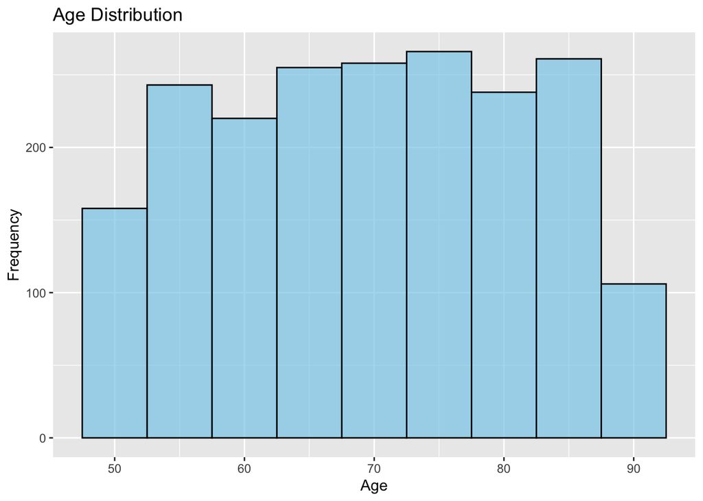

```r
library(ggplot2)
# Visualize class distribution
ggplot(df, aes(x = Age)) +
  geom_histogram(binwidth = 5, fill = "skyblue", color = "black", alpha = 0.7) +
  labs(title = "Age Distribution", x = "Age", y = "Frequency")
```

## Decision Tree

### Splitting Data into Training and Validation Sets

```r
library(lattice)
library(caret)

set.seed(9878)
trainIndex <- createDataPartition(df$Diagnosis, p = 0.8, list = FALSE)
trainData <- df[trainIndex, ]
validData <- df[-trainIndex, ]

prop.table(table(trainData$Diagnosis)) * 100
```

```
##
##       0       1
## 38.2793 61.7207
```

```r
prop.table(table(validData$Diagnosis)) * 100
```

```
##
##        0        1
## 37.15711 62.84289
```

The data is split into traing and test data for training the model. We split the model into a 80:20 split.

### Decision Tree Model

```r
library(rpart)
tree_model <- rpart(Diagnosis ~ ., data = trainData, method = "class", parms = list(split = "gini"), control = rpart.control(maxdepth = 10))
```

We create the decision tree model.

### Visualizing Decision Tree

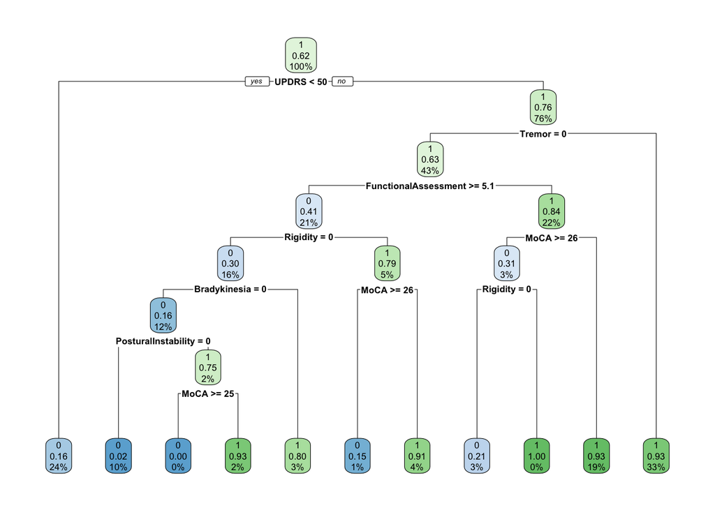

```r
library(rpart.plot)
rpart.plot(tree_model)
```

Visualization of the decision tree model.

### Model Evaluation on Validation Set

```r
## Model Evaluation on Validation Set
library(caret)

trainData$Diagnosis <- as.factor(trainData$Diagnosis)
validData$Diagnosis <- as.factor(validData$Diagnosis)

pred <- predict(tree_model, validData, type = "class")
pred <- as.factor(pred)

pred <- factor(pred, levels = levels(validData$Diagnosis))

conf_matrix <- confusionMatrix(pred, validData$Diagnosis)
conf_matrix
```

```
## Confusion Matrix and Statistics
##
##           Reference
## Prediction   0   1
##          0 132  24
##          1  17 228
##
##                Accuracy : 0.8978
##                  95% CI : (0.8639, 0.9256)
##     No Information Rate : 0.6284
##     P-Value [Acc > NIR] : <2e-16
##
##                   Kappa : 0.7831
##
##  Mcnemar's Test P-Value : 0.3487
##
##             Sensitivity : 0.8859
##             Specificity : 0.9048
##          Pos Pred Value : 0.8462
##          Neg Pred Value : 0.9306
##              Prevalence : 0.3716
##          Detection Rate : 0.3292
##    Detection Prevalence : 0.3890
##       Balanced Accuracy : 0.8953
##
##        'Positive' Class : 0
##
```

Model evaluation of the decision tree model

## Random Forest

### Ditribution of data

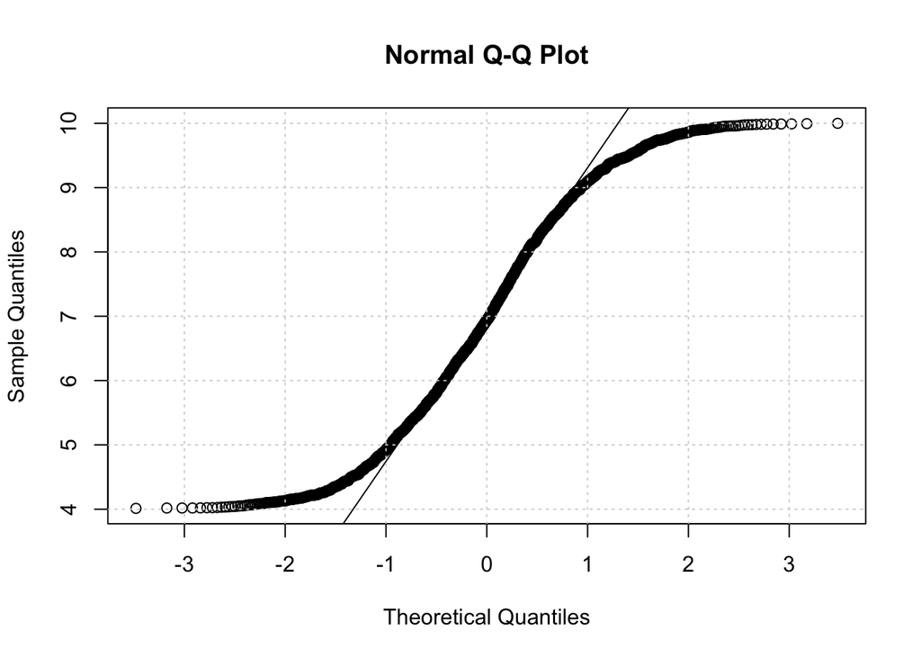

```r
z <-missing.value[1,2]
qqnorm(df[,z])
qqline(df[,z])
grid()
```

### Imputing missing value

```r
colSums(is.na(trainData))
```

```
##                PatientID                      Age           EducationLevel
##                        0                        0                        0
##                      BMI                  Smoking       AlcoholConsumption
##                        0                        0                        0
##         PhysicalActivity              DietQuality             SleepQuality
##                        0                        0                        4
##  FamilyHistoryParkinsons     TraumaticBrainInjury             Hypertension
##                        0                        0                        0
##                 Diabetes               Depression                   Stroke
##                        0                        0                        0
##               SystolicBP              DiastolicBP         CholesterolTotal
##                        0                        0                        0
##           CholesterolLDL           CholesterolHDL CholesterolTriglycerides
##                        0                        0                        0
##                    UPDRS                     MoCA     FunctionalAssessment
##                        0                        0                        0
##                   Tremor                 Rigidity             Bradykinesia
##                        0                        0                        0
##      PosturalInstability           SpeechProblems           SleepDisorders
##                        0                        0                        0
##             Constipation                Diagnosis
##                        0                        0
```

```r
class(trainData$SleepQuality)
```

```
## [1] "numeric"
```

```r
trainData$SleepQuality[is.na(trainData$SleepQuality)] <- mean(trainData$SleepQuality, na.rm = TRUE)

colSums(is.na(trainData))
```

```
##                PatientID                      Age           EducationLevel
##                        0                        0                        0
##                      BMI                  Smoking       AlcoholConsumption
##                        0                        0                        0
##         PhysicalActivity              DietQuality             SleepQuality
##                        0                        0                        0
##  FamilyHistoryParkinsons     TraumaticBrainInjury             Hypertension
##                        0                        0                        0
##                 Diabetes               Depression                   Stroke
##                        0                        0                        0
##               SystolicBP              DiastolicBP         CholesterolTotal
##                        0                        0                        0
##           CholesterolLDL           CholesterolHDL CholesterolTriglycerides
##                        0                        0                        0
##                    UPDRS                     MoCA     FunctionalAssessment
##                        0                        0                        0
##                   Tremor                 Rigidity             Bradykinesia
##                        0                        0                        0
##      PosturalInstability           SpeechProblems           SleepDisorders
##                        0                        0                        0
##             Constipation                Diagnosis
##                        0                        0
```

### Model Training

```r
library(randomForest)
set.seed(123)

rf_model <- randomForest(Diagnosis ~ ., data = trainData, ntree = 100, mtry = sqrt(ncol(trainData)-1))
print(rf_model)
```

```
##
## Call:
##  randomForest(formula = Diagnosis ~ ., data = trainData, ntree = 100,      mtry = sqrt(ncol(trainData) - 1))
##                Type of random forest: classification
##                      Number of trees: 100
## No. of variables tried at each split: 6
##
##         OOB estimate of  error rate: 9.23%
## Confusion matrix:
##     0   1 class.error
## 0 534  80  0.13029316
## 1  68 922  0.06868687
```

We created a model using random forests using randomForest() function from the randomForest package

## Logistic Regression

```r
trainData$Diagnosis <- as.numeric(as.character(trainData$Diagnosis))
log_model <- glm(Diagnosis ~ ., data = trainData, family = binomial)
summary(log_model)
```

```
##
## Call:
## glm(formula = Diagnosis ~ ., family = binomial, data = trainData)
##
## Coefficients:
##                            Estimate Std. Error z value Pr(>|z|)
## (Intercept)              -1.647e+00  1.097e+00  -1.501 0.133434
## PatientID                -3.054e-04  1.232e-04  -2.480 0.013141 *
## Age                       2.312e-02  6.375e-03   3.626 0.000288 ***
## EducationLevel           -2.220e-01  1.910e-01  -1.162 0.245158
## BMI                       1.633e-02  1.030e-02   1.586 0.112772
## Smoking                  -1.433e-01  1.608e-01  -0.891 0.372804
## AlcoholConsumption        2.095e-03  1.290e-02   0.162 0.870951
## PhysicalActivity          1.556e-02  2.532e-02   0.615 0.538862
## DietQuality              -2.463e-02  2.544e-02  -0.968 0.332953
## SleepQuality             -7.128e-02  4.213e-02  -1.692 0.090640 .
## FamilyHistoryParkinsons   1.891e-01  2.103e-01   0.899 0.368616
## TraumaticBrainInjury      5.311e-01  2.420e-01   2.195 0.028199 *
## Hypertension             -2.222e-02  2.104e-01  -0.106 0.915892
## Diabetes                  3.249e-01  2.045e-01   1.588 0.112177
## Depression                5.800e-01  1.819e-01   3.189 0.001429 **
## Stroke                    7.549e-01  3.605e-01   2.094 0.036265 *
## SystolicBP               -7.627e-05  2.758e-03  -0.028 0.977934
## DiastolicBP              -4.265e-03  4.226e-03  -1.009 0.312799
## CholesterolTotal          7.198e-04  1.688e-03   0.426 0.669808
## CholesterolLDL           -1.856e-04  1.658e-03  -0.112 0.910849
## CholesterolHDL            1.111e-03  3.094e-03   0.359 0.719637
## CholesterolTriglycerides -5.923e-05  7.154e-04  -0.083 0.934017
## UPDRS                     2.767e-02  1.682e-03  16.455  < 2e-16 ***
## MoCA                     -7.163e-02  8.840e-03  -8.103 5.37e-16 ***
## FunctionalAssessment     -3.229e-01  2.801e-02 -11.529  < 2e-16 ***
## Tremor                    2.421e+00  1.754e-01  13.802  < 2e-16 ***
## Rigidity                  2.159e+00  1.977e-01  10.916  < 2e-16 ***
## Bradykinesia              1.985e+00  2.113e-01   9.396  < 2e-16 ***
## PosturalInstability       2.036e+00  2.480e-01   8.210  < 2e-16 ***
## SpeechProblems            3.881e-02  1.605e-01   0.242 0.808878
## SleepDisorders           -3.136e-01  1.700e-01  -1.844 0.065127 .
## Constipation              1.832e-01  1.632e-01   1.123 0.261519
## ---
## Signif. codes:  0 '***' 0.001 '**' 0.01 '*' 0.05 '.' 0.1 ' ' 1
##
## (Dispersion parameter for binomial family taken to be 1)
##
##     Null deviance: 2134.7  on 1603  degrees of freedom
## Residual deviance: 1197.1  on 1572  degrees of freedom
## AIC: 1261.1
##
## Number of Fisher Scoring iterations: 6
```

We trained a logistic regression model using generalized linear regression function and setting the family as binomial, since the outcome is binary (Yes/No).

## Ensemble Method

```r
f1_score <- function(actual, predicted) {
  cm <- confusionMatrix(predicted, actual, positive = "1")
  precision <- cm$byClass["Precision"]
  recall <- cm$byClass["Recall"]
  f1 <- 2 * ((precision * recall) / (precision + recall))
  return(f1)
}

# Decision Tree Predictions
pred <- predict(tree_model, trainData, type = "class")
f1_dt <- f1_score(as.factor(trainData$Diagnosis), pred)

# Random Forest Predictions
rf_pred <- predict(rf_model, trainData, type = "class")
f1_rf <- f1_score(as.factor(trainData$Diagnosis), rf_pred)

# Logistic Regression Predictions
log_prob <- predict(log_model, trainData, type = "response")
log_pred <- ifelse(log_prob > 0.5, 1, 0)
f1_log <- f1_score(as.factor(trainData$Diagnosis), as.factor(log_pred))

cat("Decision Tree F1-Score:", f1_dt, "\n")
```

```
## Decision Tree F1-Score: 0.9223007
```

```r
cat("Random Forest F1-Score:", f1_rf, "\n")
```

```
## Random Forest F1-Score: 1
```

```r
cat("Logistic Regression F1-Score:", f1_log, "\n")
```

```
## Logistic Regression F1-Score: 0.8642466
```

We created an Ensemble model to combine the results of the 3 model to maximise the accuracy of the result.

```r
# Decision Tree Prediction
valid_dt_pred <- predict(tree_model, validData, type = "class")

# Random Forest Prediction
valid_rf_pred <- predict(rf_model, validData, type = "class")

# Logistic Regression Prediction
valid_log_prob <- predict(log_model, validData, type = "response")
valid_log_pred <- ifelse(valid_log_prob > 0.5, 1, 0)

# Ensemble prediction using majority vote
valid_predictions <- data.frame(
  dt = as.numeric(as.character(valid_dt_pred)),
  rf = as.numeric(as.character(valid_rf_pred)),
  log = valid_log_pred
)

ensemble_valid_pred <- apply(valid_predictions, 1, function(x) {
  if(sum(x) >= 2) {1} else {0}
})

output <- data.frame(
  PatientID = validData$PatientID,
  PredictedDiagnosis = ensemble_valid_pred
)

output <- output[order(output$PatientID), ] # Sorted by PatientID in ascending order
head(output)
```

```
##    PatientID PredictedDiagnosis
## 2       3059                  0
## 4       3062                  0
## 8       3067                  0
## 14      3073                  1
## 15      3074                  1
## 19      3078                  1
```

```r
write.csv(output, file = "DawareA.Predications.csv", row.names = FALSE)
```

## Ensemble model f1 score

```r
library(caret)

# Convert predictions and actual values to factors
ensemble_valid_pred <- factor(ensemble_valid_pred, levels = c(0, 1))
validData$Diagnosis <- factor(validData$Diagnosis, levels = c(0, 1))

# Compute confusion matrix
conf_matrix <- confusionMatrix(ensemble_valid_pred, validData$Diagnosis)

# Extract precision and recall
precision <- conf_matrix$byClass["Precision"]
precision
```

```
## Precision
## 0.8684211
```

```r
recall <- conf_matrix$byClass["Recall"]
recall
```

```
##   Recall
## 0.885906
```

```r
# Compute F1-score
f1.score<-function(p,r){
  score <- (2 * ((p*r)/(p+r)))
  return(score)
}
score <- f1.score(precision,recall)
```

The F1 score of the ensemble model was found to be 0.8770764.